# Introduction

[output not shown]

[output not shown]

[output not shown]

[output not shown]

[output not shown]

[output not shown]

[output not shown]

[output not shown]

[output not shown]

[output not shown]

[output not shown]

[output not shown]

[output not shown]

[output not shown]

[output not shown]

[output not shown]

[output not shown]

[output not shown]

[output not shown]

[output not shown]

[output not shown]

[output not shown]

[output not shown]

[output not shown]

[output not shown]

[output not shown]

[output not shown]

[output not shown]

[output not shown]

[output not shown]

[output not shown]

[output not shown]

[output not shown]

[output not shown]

[output not shown]

[output not shown]

[output not shown]

[output not shown]

[output not shown]

[output not shown]

[output not shown]

[output not shown]

[output not shown]

[output not shown]

[output not shown]

[output not shown]

[output not shown]

[output not shown]

[output not shown]

[output not shown]

[output not shown]

[output not shown]

[output not shown]

[output not shown]

[output not shown]

[output not shown]

[output not shown]

[output not shown]

[output not shown]

[output not shown]

[output not shown]

[output not shown]

[output not shown]

[output not shown]

[output not shown]

[output not shown]

[output not shown]

[output not shown]

[output not shown]

[output not shown]

[output not shown]

[output not shown]

[output not shown]

[output not shown]

[output not shown]

[output not shown]

[output not shown]

[output not shown]

[output not shown]

[output not shown]

[output not shown]

[output not shown]

[output not shown]

[output not shown]

[output not shown]

[output not shown]

[output not shown]

[output not shown]

[output not shown]

[output not shown]

[output not shown]

[output not shown]

[output not shown]

[output not shown]

[output not shown]

[output not shown]

[output not shown]

[output not shown]

[output not shown]

[output not shown]

[output not shown]

[output not shown]

[output not shown]

[output not shown]

[output not shown]

[output not shown]

[output not shown]

[output not shown]

[output not shown]

[output not shown]

[output not shown]

[output not shown]

[output not shown]

[output not shown]

[output not shown]

[output not shown]

[output not shown]

[output not shown]

[output not shown]

[output not shown]

[output not shown]

[output not shown]

[output not shown]

[output not shown]

[output not shown]

[output not shown]

[output not shown]

[output not shown]

[output not shown]

[output not shown]

[output not shown]

[output not shown]

[output not shown]

[output not shown]

[output not shown]

[output not shown]

[output not shown]

[output not shown]

[output not shown]

[output not shown]

[output not shown]

[output not shown]

[output not shown]

[output not shown]

[output not shown]

[output not shown]

[output not shown]

[output not shown]

[output not shown]

[output not shown]

[output not shown]

[output not shown]

[output not shown]

[output not shown]

[output not shown]

[output not shown]

[output not shown]

[output not shown]

[output not shown]

[output not shown]

[output not shown]

[output not shown]

[output not shown]

[output not shown]

[output not shown]

[output not shown]

[output not shown]

[output not shown]

[output not shown]

[output not shown]

[output not shown]

[output not shown]

[output not shown]

[output not shown]

[output not shown]

[output not shown]

[output not shown]

[output not shown]

[output not shown]

[output not shown]

[output not shown]

[output not shown]

[output not shown]

[output not shown]

[output not shown]

[output not shown]

[output not shown]

[output not shown]

[output not shown]

[output not shown]

[output not shown]

[output not shown]

[output not shown]

[output not shown]

[output not shown]

[output not shown]

[output not shown]

[output not shown]

[output not shown]

[output not shown]

[output not shown]

[output not shown]

[output not shown]

[output not shown]

[output not shown]

[output not shown]

[output not shown]

[output not shown]

[output not shown]

[output not shown]

[output not shown]

[output not shown]

[output not shown]

[output not shown]

[output not shown]

[output not shown]

[output not shown]

[output not shown]

[output not shown]

[output not shown]

[output not shown]

[output not shown]

[output not shown]

[output not shown]

[output not shown]

[output not shown]

[output not shown]

[output not shown]

## Part 4 Test generalizability

The trained model will now be tested on molecules with 5 heavy atoms. The number of trainable parameters printed are the number of parameters per atomic subnetwork. Therefore, this number can be multiplied by four to find the total number of trainable parameters for the molecular model. Three separate cells are provided to show the evaluation error for each model. In order to redo this, load each model first by initializing the model in part 2.1 and then loading the model with the first cell of this section.

```python
# Select model to load
# Must build model first (part 2.1) to load state dict.
# model.load_state_dict(torch.load("./ANI_model_state_dict.pth"))
# model.load_state_dict(torch.load("./ResNet_model_state_dict.pth"))
# model.load_state_dict(torch.load("./Linear_model_state_dict.pth"))
```

[output not shown]

```python
test_path = "../Data/ANI-1_release/ani_gdb_s05.h5"

testing = torchani.data.load(test_path)\
                       .subtract_self_energies(energy_shifter, species_order)\
                       .species_to_indices(species_order)\
                       .shuffle()\
                       .collate(batch_size)\
                       .cache()
```

```python
# Recreated ANI model
print(f"(ANI) Evaluation RMSE for 5 heavy atoms: {validate(testing)} kcal/mol")
print(f'Trainable parameters: {385*128 + 129*64 + 65}')
model
```

```
(ANI) Evaluation RMSE for 5 heavy atoms: 27.41153893526561 kcal/mol
Trainable parameters: 57601
```

```
Sequential(
  (0): AEVComputer()
  (1): ANIModel(
    (0): Sequential(
      (0): Linear(in_features=384, out_features=128, bias=True)
      (1): GELU(approximate='none')
      (2): Linear(in_features=128, out_features=64, bias=True)
      (3): GELU(approximate='none')
      (4): Linear(in_features=64, out_features=1, bias=True)
    )
    (1): Sequential(
      (0): Linear(in_features=384, out_features=128, bias=True)
      (1): GELU(approximate='none')
      (2): Linear(in_features=128, out_features=64, bias=True)
      (3): GELU(approximate='none')
      (4): Linear(in_features=64, out_features=1, bias=True)
    )
    (2): Sequential(
      (0): Linear(in_features=384, out_features=128, bias=True)
      (1): GELU(approximate='none')
      (2): Linear(in_features=128, out_features=64, bias=True)
      (3): GELU(approximate='none')
      (4): Linear(in_features=64, out_features=1, bias=True)
    )
    (3): Sequential(
      (0): Linear(in_features=384, out_features=128, bias=True)
      (1): GELU(approximate='none')
      (2): Linear(in_features=128, out_features=64, bias=True)
      (3): GELU(approximate='none')
      (4): Linear(in_features=64, out_features=1, bias=True)
    )
  )
)
```

```python
# ResNet Model
print(f"(ResNet) Evaluation RMSE for 5 heavy atoms: {validate(testing)} kcal/mol")
print(f'Trainable parameters: {385*128 + 129*64 + 65 + 385}')
model
```

```
(ResNet) Evaluation RMSE for 5 heavy atoms: 46.295844683529005 kcal/mol
Trainable parameters: 57986
```

```
Sequential(
  (0): AEVComputer()
  (1): ANIModel(
    (0): ANI_Res_sub(
      (architecture): ModuleList(
        (0): Linear(in_features=384, out_features=128, bias=True)
        (1): GELU(approximate='none')
        (2): Linear(in_features=128, out_features=64, bias=True)
        (3): GELU(approximate='none')
        (4): Linear(in_features=64, out_features=1, bias=True)
      )
      (skip_connection): Linear(in_features=384, out_features=1, bias=True)
    )
    (1): ANI_Res_sub(
      (architecture): ModuleList(
        (0): Linear(in_features=384, out_features=128, bias=True)
        (1): GELU(approximate='none')
        (2): Linear(in_features=128, out_features=64, bias=True)
        (3): GELU(approximate='none')
        (4): Linear(in_features=64, out_features=1, bias=True)
      )
      (skip_connection): Linear(in_features=384, out_features=1, bias=True)
    )
    (2): ANI_Res_sub(
      (architecture): ModuleList(
        (0): Linear(in_features=384, out_features=128, bias=True)
        (1): GELU(approximate='none')
        (2): Linear(in_features=128, out_features=64, bias=True)
        (3): GELU(approximate='none')
        (4): Linear(in_features=64, out_features=1, bias=True)
      )
      (skip_connection): Linear(in_features=384, out_features=1, bias=True)
    )
    (3): ANI_Res_sub(
      (architecture): ModuleList(
        (0): Linear(in_features=384, out_features=128, bias=True)
        (1): GELU(approximate='none')
        (2): Linear(in_features=128, out_features=64, bias=True)
        (3): GELU(approximate='none')
        (4): Linear(in_features=64, out_features=1, bias=True)
      )
      (skip_connection): Linear(in_features=384, out_features=1, bias=True)
    )
  )
)
```

```python
# Linear Model
print(f"(Linear) Evaluation RMSE for 5 heavy atoms: {validate(testing)} kcal/mol")
print(f'Trainable parameters: {385}')
model
```

```
(Linear) Evaluation RMSE for 5 heavy atoms: 73.37776157129487 kcal/mol
Trainable parameters: 385
```

```
Sequential(
  (0): AEVComputer()
  (1): ANIModel(
    (0): Sequential(
      (0): Linear(in_features=384, out_features=1, bias=True)
    )
    (1): Sequential(
      (0): Linear(in_features=384, out_features=1, bias=True)
    )
    (2): Sequential(
      (0): Linear(in_features=384, out_features=1, bias=True)
    )
    (3): Sequential(
      (0): Linear(in_features=384, out_features=1, bias=True)
    )
  )
)
```

# Part 5 Visualization

These plots are recreations of what can be found in tensorboard. Tensorboard was primarily used to record training and validation loss. The data from tensorboard was downloaded as a csv and stored in the subdirectory `./loss_data`. There is a section inside the double for loop where one can comment or uncomment code to zoom-in or change the scale. Currently it is set to display the full y-range and logarithmically scale the y-axis to better see if the loss is decreasing.

### Side-by-side plots

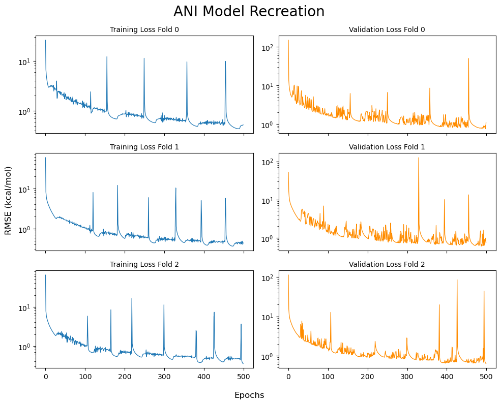

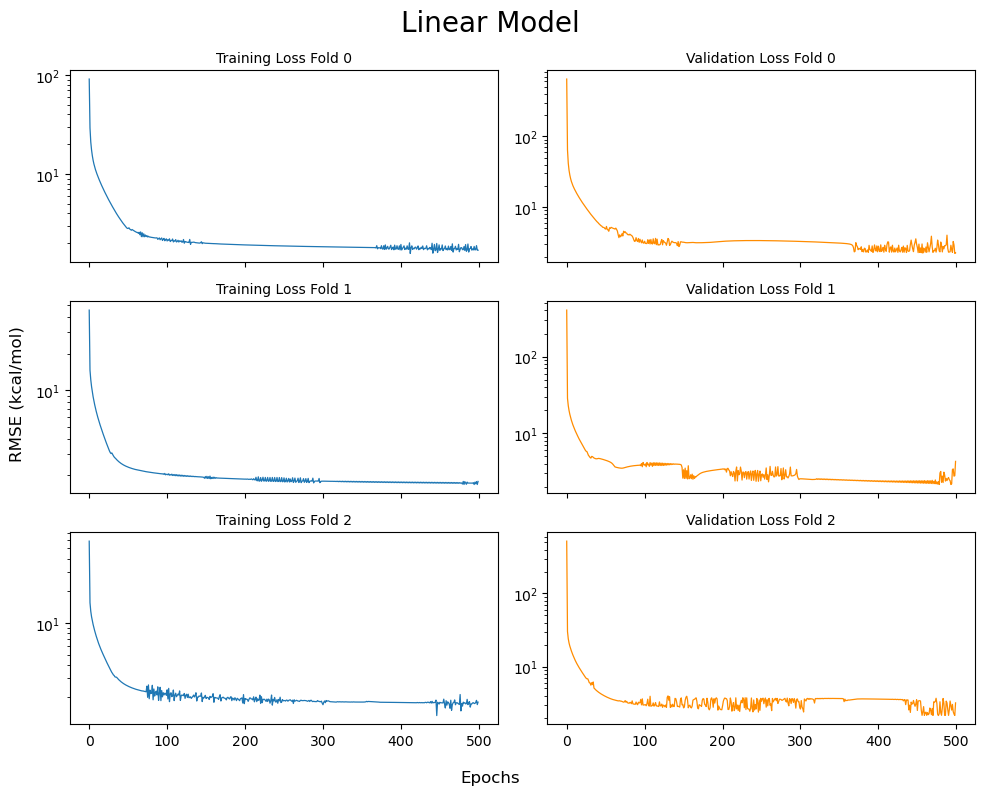

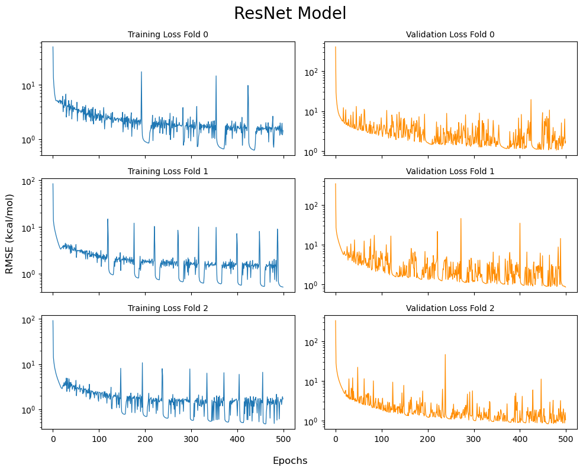

```python
# Make list of files
file_list = os.listdir("./loss_data/")
file_list.sort()
file_list

# store losses to report
training_loss = {'ANI Model Recreation' : [],
                 'Linear Model' : [],
                 'ResNet Model' : []}
validation_loss = {'ANI Model Recreation' : [],
                   'Linear Model' : [],
                   'ResNet Model' : []}

for model in ['ANI Model Recreation', 'Linear Model', 'ResNet Model']:
    fig, axs = plt.subplots(3, 2,
                        figsize=(10,8),
                        sharex=True,
                        sharey=False,
                        )
    # Plot data in each subplot
    for i in range(2):
        for ii in range(3):
            df = pd.read_csv("./loss_data/"+file_list[3*i+ii])
            x = df['Step'].to_numpy()
            y = df['Value'].to_numpy()

            if i == 0:
                axs[ii, i].set_title(f'Training Loss Fold {ii}', fontsize=10)
                axs[ii, i].plot(x, y, linewidth=0.9)
                training_loss[model].append(y[-1])
            else:
                axs[ii, i].set_title(f'Validation Loss Fold {ii}', fontsize=10)
                axs[ii, i].plot(x, y, color='darkorange', linewidth=0.9)
                validation_loss[model].append(y[-1])

            #
            # Adjustments change y_lim and yscale.
            #
            # axs[ii,i].set_ylim(0.5,5)
            axs[ii,i].set_yscale('log')

    # Titles
    fig.suptitle(model, fontsize=20)
    fig.supxlabel('Epochs', fontsize=12)
    fig.supylabel('RMSE (kcal/mol)', fontsize=12)
    fig.tight_layout()

    # Remove plotted files paths from list
    for _ in range(6):
        file_list.pop(0)
```

### Overlayed plots

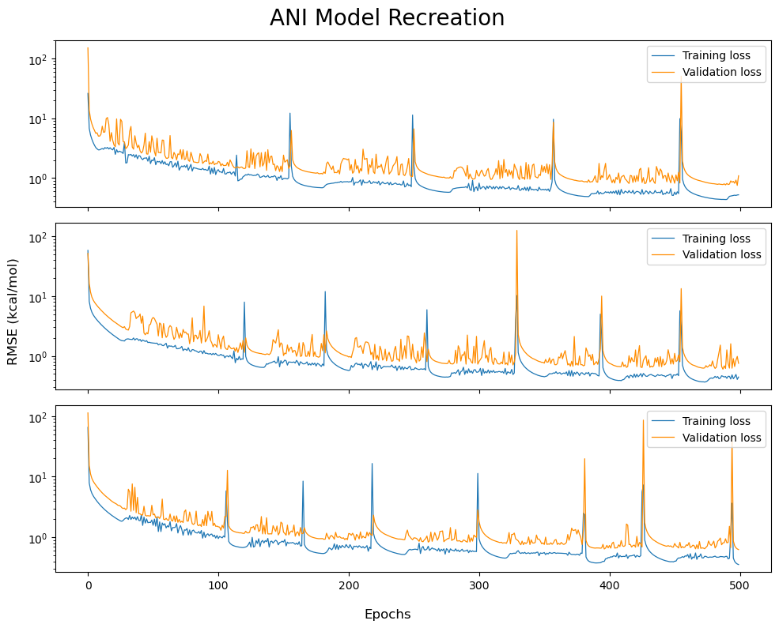

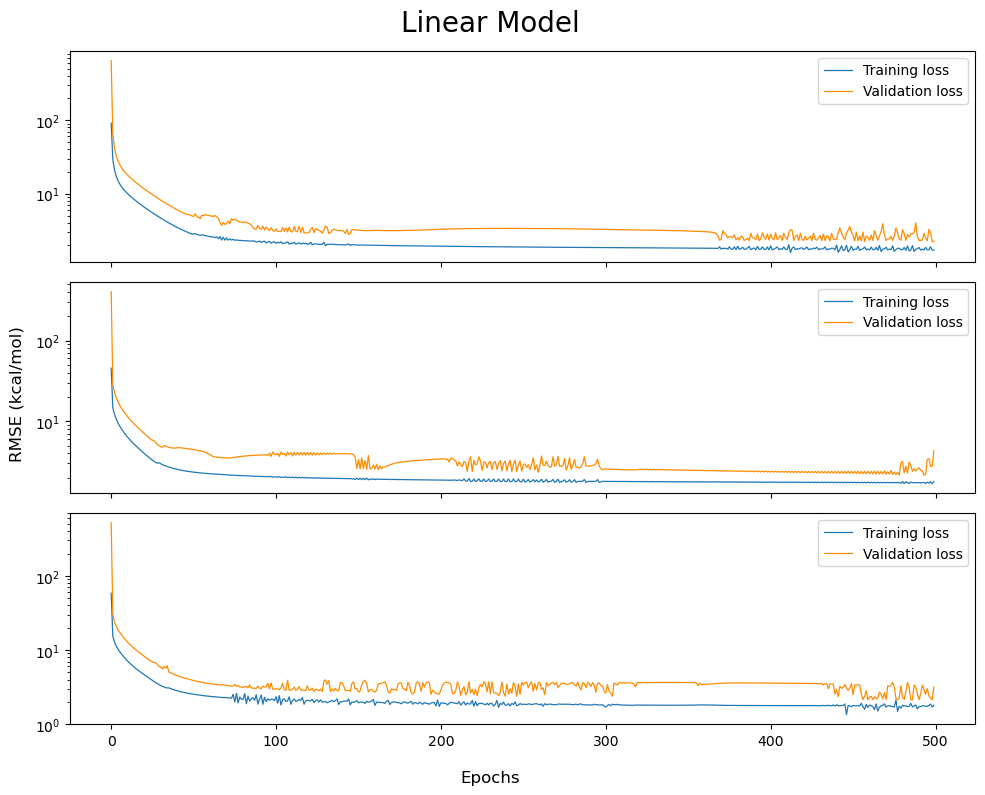

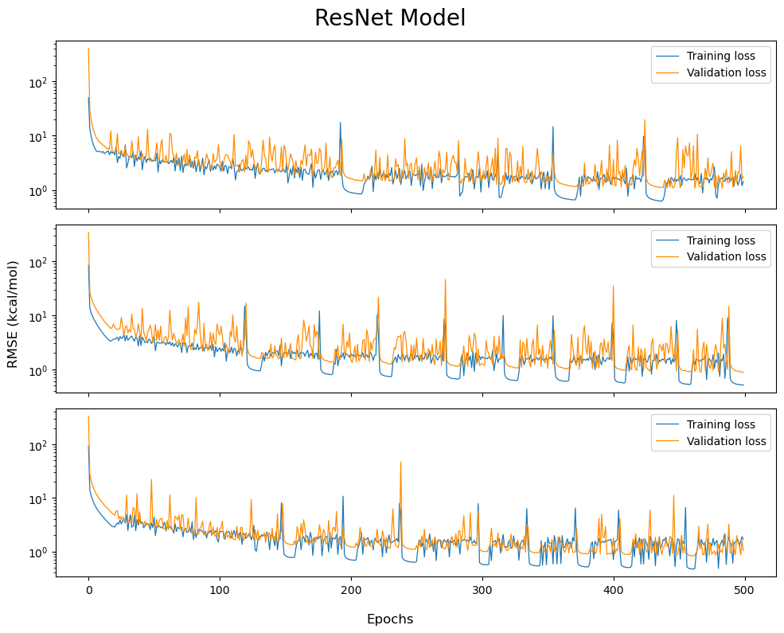

```python
# Make list of files
file_list = os.listdir("./loss_data/")
file_list.sort()
file_list

# store losses to report
training_loss = {'ANI Model Recreation' : [],
                 'Linear Model' : [],
                 'ResNet Model' : []}
validation_loss = {'ANI Model Recreation' : [],
                   'Linear Model' : [],
                   'ResNet Model' : []}

for model in ['ANI Model Recreation', 'Linear Model', 'ResNet Model']:
    fig, axs = plt.subplots(3, 1,
                        figsize=(10,8),
                        sharex=True,
                        sharey=False,
                        )
    # Plot data in each subplot
    for i in range(2):
        for ii in range(3):
            df = pd.read_csv("./loss_data/"+file_list[3*i+ii])
            x = df['Step'].to_numpy()
            y = df['Value'].to_numpy()

            if i == 0:
                # axs[ii].set_title(f'Training Loss Fold {ii}', fontsize=10)
                axs[ii].plot(x, y, linewidth=0.9, label='Training loss')
                training_loss[model].append(y[-1])
            else:
                # axs[ii].set_title(f'Validation Loss Fold {ii}', fontsize=10)
                axs[ii].plot(x, y, color='darkorange', linewidth=0.9, label='Validation loss')
                validation_loss[model].append(y[-1])

            #
            # Adjustments change y_lim and yscale.
            #
            # axs[ii].set_ylim(0.5,5)
            axs[ii].set_yscale('log')
            axs[ii].legend(loc='upper right')

    # Titles
    fig.suptitle(model, fontsize=20)
    fig.supxlabel('Epochs', fontsize=12)
    fig.supylabel('RMSE (kcal/mol)', fontsize=12)
    fig.tight_layout()

    # Remove plotted files paths from list
    for _ in range(6):
        file_list.pop(0)
```

# Part 6 Report average losses

This displays two dataframes that show either the training or validation loss of the last epoch for each fold. The average of the 3 folds is also displayed.As seen below, the 'ANI Model Recreation' had the lowest average training loss with an RMSE of ~0.44005 kcla/mol. This model also had the lowest average validation loss with an RMSE of ~0.8227 kcal/mol. The next best model was the 'ResNet Model' with an average training RMSE of ~1.2076 kcal/mol and an average validation RMSE of ~1.2224 kcal/mol. Finally, the 'Linear model' performed the worst with an average training RMSE of ~1.7604 kcal/mol and an average validation RMSE of ~3.2427 kcal/mol.

```python
# Compile training losses and average loss of last epoch
training_loss_df = pd.DataFrame(training_loss)
training_loss_df.loc[len(training_loss_df)] = [np.mean(training_loss_df['ANI Model Recreation']),
                                               np.mean(training_loss_df['Linear Model']),
                                               np.mean(training_loss_df['ResNet Model'])]
training_loss_df.set_index(np.array(['Fold 0', 'Fold 1', 'Fold 2', 'Average']), inplace=True)
print('Training loss dataframe:')
display(training_loss_df)

# Repeat for validation lossess
validation_loss_df = pd.DataFrame(validation_loss)
validation_loss_df.loc[len(validation_loss_df)] = [np.mean(validation_loss_df['ANI Model Recreation']),
                                                   np.mean(validation_loss_df['Linear Model']),
                                                   np.mean(validation_loss_df['ResNet Model'])]
validation_loss_df.set_index(np.array(['Fold 0', 'Fold 1', 'Fold 2', 'Average']), inplace=True)
print('Validation loss dataframe:')
display(validation_loss_df)
```

```
Training loss dataframe:
```

|  | ANI Model Recreation | Linear Model | ResNet Model |
| --- | --- | --- | --- |
| Fold 0 | 0.523204 | 1.699342 | 1.436293 |
| Fold 1 | 0.444109 | 1.786350 | 0.510526 |
| Fold 2 | 0.354142 | 1.795488 | 1.675943 |
| Average | 0.440485 | 1.760393 | 1.207587 |

```
Validation loss dataframe:
```

|  | ANI Model Recreation | Linear Model | ResNet Model |
| --- | --- | --- | --- |
| Fold 0 | 1.090423 | 2.254041 | 1.762758 |
| Fold 1 | 0.752390 | 4.299759 | 0.870335 |
| Fold 2 | 0.625291 | 3.174407 | 1.034211 |
| Average | 0.822701 | 3.242736 | 1.222435 |

# Conclusion

It was found that the recreated ANI1 model performed the best showing the lowest average training, validation, and evaluation loss. The other two models did not train as quickly given the same parameters (number of epochs, optimizer, learning rate, etc.). Something that can be seen in the plots produced for each model is that both the ResNet and the ANI model produced periodic spikes in the loss and validation curves that were not present with the linear model training. While the linear model did not train to a lower loss than the other models, it appears that it was more resiliant to fluctuations in the dataset that produced these large loss spikes. Adding the linear features back into the model through the skip connection caused more noise to be introduced into the baseline when compared to the recreated ANI model.

With more time it would be worth training all three of these models significantly longer to see if the peridoic loss spikes disipate, or if the linear model continues to learn past the other two models. It would also be interesting to see how the ResNet's noisy baseline evolves over time. Based on the profile of the training and validation curves alone, it seems that the linear regression had the most consistent training and perhaps these characteristics can be transfered to the other models. Further development of the ResNet's architecture should be explored to see if there is a manner where this can be done.

| Model | Avg Training RMSE | Avg Validation RMSE | Evaluation RMSE | Trainable Parameters* |
| --- | --- | --- | --- | --- |
| ANI | 0.4404849608739217 | 0.8227014740308126 | 27.41153893526561 | 57601 |
| ResNet | 1.2075873613357544 | 1.2224349180857341 | 46.295844683529005 | 57986 |
| Linear | 1.7603933413823445 | 3.2427359422047934 | 73.37776157129487 | 385 |

*Trainable parameters are the number of parameters for each subnetwork.